# Getting started with mvrem

mvrem fits **multivariate joint models** with INLA: several longitudinal markers and one or more outcomes, each with its own family, fixed effects and random effects. An outcome is linked to a marker through a scaled copy of the marker’s linear predictor: the term `scaled(x)` in the outcome’s formula adds $\gamma \, \eta_x$ to it, with $\eta_x$ the marker’s fixed + random effects evaluated at the outcome’s covariates (its time, subject, …), and $\gamma$ estimated. The marker and the outcome need not be measured at the same times.

The whole model is written in lme4 notation and fitted with one call, `jsm()`; INLA’s interface (stacked data, `f()` terms, copies) is built and hidden by the package.

## Installation

INLA is not on CRAN; install it first, then mvrem from GitHub (`htmlwidgets` is optional and makes the plots interactive):

```r
install.packages("INLA",
                 repos = c(getOption("repos"),
                           INLA = "https://inla.r-inla-download.org/R/stable"),
                 dep = TRUE)
install.packages(c("remotes", "htmlwidgets"))
remotes::install_github("LUMC/mvrem")
```

```r
library(mvrem)
```

## A first model: one outcome, one marker

Simulated data, so the estimates can be compared with the truth: 100 subjects, a Gaussian marker `x1` with a correlated random intercept and slope, measured at `t = 0, 0.5, 1, 1.5`, and a beta-distributed outcome `y` measured **between** these visits. The outcome depends on the marker’s current (error-free) value with $\gamma = 0.8$.

```r
set.seed(1)
n <- 100
ids <- sprintf("S%03d", seq_len(n))
dX <- data.frame(id = rep(ids, each = 4), t = rep(c(0, 0.5, 1, 1.5), n))         # marker visits
dY <- data.frame(id = rep(ids, each = 4), t = rep(c(0.25, 0.75, 1.25, 1.75), n))  # outcome times
z0 <- rnorm(n); z1 <- 0.6 * z0 + sqrt(1 - 0.6^2) * rnorm(n)
b0 <- 0.5 * z0; b1 <- 0.2 * z1                # random intercept (SD 0.5), slope (SD 0.2), cor 0.6
eta <- function(d) { i <- match(d$id, ids); 1 + 0.5 * d$t + b0[i] + b1[i] * d$t }
dX$x1 <- eta(dX) + rnorm(nrow(dX), sd = 0.2)                    # marker
mu <- plogis(-1 + 0.8 * eta(dY))                               # gamma = 0.8
dY$y <- rbeta(nrow(dY), 20 * mu, 20 * (1 - mu))                # outcome, phi = 20
dY$y[sample(nrow(dY), 60)] <- NA                               # missing outcomes are predicted
head(dY, 3)
```

```
#>     id    t         y
#> 1 S001 0.25 0.3630654
#> 2 S001 0.75 0.6428514
#> 3 S001 1.25 0.5363252
```

```r
head(dX, 3)
```

```
#>     id   t        x1
#> 1 S001 0.0 0.7686535
#> 2 S001 0.5 1.1873312
#> 3 S001 1.0 1.3296577
```

### The model

All formulae go in one list. A formula with a `scaled()` term is an outcome, one without is a marker. Random effects are written as in lme4, `(1 + t | id)`, or with `re()` to set their prior; here the Wishart prior of the block is centred on an lme4 fit of the marker (`scale = "data"`). The data are given per response; families default to Gaussian.

```r
m <- jsm(
  list(y  ~ 1 + t + scaled(x1),
       x1 ~ 1 + t + re(1 + t | id, prior = wishartPrec(scale = "data"))),
  data   = list(y = dY, x1 = dX),
  family = list(y = betaFamily()),
  criteria = TRUE                     # DIC, WAIC and CPO for modelFit()
)
summary(m)
```

```
#> Call:
#> jsm(form = list(y ~ 1 + t + scaled(x1), x1 ~ 1 + t + re(1 + t | id, prior = wishartPrec(scale = "data"))),
#>     data = list(y = dY, x1 = dX), family = list(y = betaFamily()), criteria = TRUE)
#>
#> Fixed effects (posterior):
#>  response        term   mean     sd  q0.025   q0.5 q0.975
#>         y (Intercept)  -1.06 0.0774   -1.21  -1.06 -0.906
#>         y           t 0.0336 0.0537 -0.0723 0.0338  0.138
#>        x1 (Intercept)   1.05 0.0495   0.955   1.05   1.15
#>        x1           t   0.51 0.0263   0.458   0.51  0.561
#>
#> Associations (gamma, posterior):
#>  outcome longitudinal  mean     sd q0.025  q0.5 q0.975
#>        y           x1 0.829 0.0506   0.73 0.828  0.929
#>
#> Hyperparameters (posterior; precisions):
#>  response                          parameter  mean    sd q0.025  q0.5 q0.975
#>         y                                phi    19  1.49   16.2    19   22.1
#>        x1                 residual precision  21.6  2.02   17.8  21.5   25.8
#>        x1      precision of (Intercept) | id  4.87 0.771   3.51  4.81   6.54
#>        x1                precision of t | id    34  9.53   19.4  32.7   56.6
#>        x1 correlation of (Intercept), t | id 0.565 0.139  0.261 0.577  0.801
```

True values: $\gamma = 0.8$, $\phi = 20$; `y` intercept $-1$, no effect of `t`; `x1` intercept 1, slope 0.5, SDs 0.5 and 0.2, correlation 0.6, residual SD 0.2.

### Results

`estimatesTable()` collects all estimates (fixed effects, associations, SDs and correlations, family parameters) in one table; `format(..., "markdown")` or `"latex"` writes it for a report.

```r
cat(format(estimatesTable(m), "markdown", digits = 2))
```

| response | parameter | mean (sd) | 95% interval |
| --- | --- | --- | --- |
| y | (Intercept) | -1.1 (0.077) | [-1.2, -0.91] |
|  | t | 0.034 (0.054) | [-0.072, 0.14] |
|  | gamma (x1 -> y) | 0.83 (0.051) | [0.73, 0.93] |
|  | phi | 19 (1.5) | [16, 22] |
| x1 | (Intercept) | 1.1 (0.049) | [0.95, 1.1] |
|  | t | 0.51 (0.026) | [0.46, 0.56] |
|  | SD (Intercept) \| id | 0.46 (0.036) | [0.39, 0.53] |
|  | SD t \| id | 0.18 (0.024) | [0.13, 0.23] |
|  | corr (Intercept), t \| id | 0.57 (0.14) | [0.26, 0.8] |
|  | residual SD | 0.22 (0.01) | [0.2, 0.24] |

`plot()` shows the data of each equation, one line per subject, and after the fit the fitted values (open circles: predictions of the missing outcomes). With htmlwidgets installed the plot is interactive: hovering a subject highlights it in all panels, a click pins it.

```r
plot(m)
```

[interactive chart not shown]

Further accessors: `fixedEffects()`, `associations()`, `hyperparameters()`, `randomEffects()`, `varianceComponents()` (SDs and correlations rather than INLA’s precisions), `fittedValues()`, `residuals()` and `modelFit()`:

```r
varianceComponents(m)
```

```
#> Variance components (posterior summaries; scale = sd)
#>
#>                     block   parameter      effect effect2  mean     sd q0.025  q0.5
#>  x1 | id [(Intercept), t]          sd (Intercept)    <NA> 0.458 0.0360  0.392 0.456
#>  x1 | id [(Intercept), t]          sd           t    <NA> 0.176 0.0238  0.133 0.175
#>  x1 | id [(Intercept), t] correlation (Intercept)       t 0.565 0.1390  0.261 0.577
#>                  residual          sd    residual    <NA> 0.216 0.0100  0.197 0.216
#>  q0.975
#>   0.533
#>   0.227
#>   0.801
#>   0.237
#>
#> x1 | id [(Intercept), t]: covariance (from posterior mean SDs and correlations)
#>             (Intercept)      t
#> (Intercept)      0.2090 0.0456
#> t                0.0456 0.0311
```

```r
modelFit(m)
```

```
#>       response         dic        waic    logScore cpoFailures      mlik
#> 1            y  -540.91000  -540.73585  -270.27694           0        NA
#> 2           x1    28.12843    31.42257    25.12802           0        NA
#> 3 observations  -512.78157  -509.31328  -245.14892           0        NA
#> 4      overall -2977.67737 -3096.90379 -1138.71942           0 -1480.782
```

and plots of them: `plotFixedEffects()`, `plotAssociations()`, `plotRandomEffects()`, `plotVarianceComponents()`, `plotResiduals()`.

```r
plotRandomEffects(m, type = "pairs")
```

[interactive chart not shown]

### Predictions

`predict()` gives the posterior of the fitted mean at new rows: new subjects (random effects from their distribution) or new times of known subjects (their own random effects).

```r
new <- data.frame(id = rep(c("S001", "S002", "new"), each = 5),
                  t  = rep(seq(0, 2, by = 0.5), 3))
p <- predict(m, new)
head(p, 3)
```

```
#>   response   id   t      mean         sd    q0.025      q0.5    q0.975      mode
#> 1        y S001 0.0 0.4088924 0.02656838 0.3575176 0.4086201 0.4618203 0.4080837
#> 2        y S001 0.5 0.4496728 0.02193397 0.4064923 0.4497244 0.4925678 0.4498397
#> 3        y S001 1.0 0.4912394 0.02263644 0.4464056 0.4913863 0.5352468 0.4916919
#> Predictions by refitting with INLA; chosen automatically: the fit has no INLA configurations.
```

```r
plot(p)
```

[interactive chart not shown]

### The model in a picture and in equations

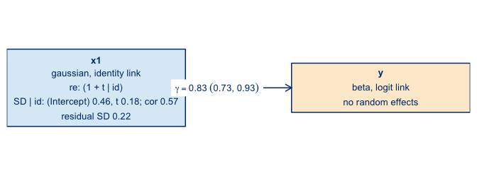

```r
plotModel(m)
```

`latexEquation()` writes the model as LaTeX; with `annotate = "tooltip"` hovering a symbol shows its estimate (`"inline"` writes the estimates under the symbols).

```r
cat(format(latexEquation(m, annotate = "tooltip"), delim = "$$"))
```

$$\begin{aligned}
\htmlData{par=response x1 (longitudinal),item=observed,mean=1.43,lo=-0.164,hi=3.66,band=range,note=400 observations}{x_{1,i}} &= \htmlData{par=fixed effect of (Intercept) in x1,mean=1.05,sd=0.0495,lo=0.955,hi=1.15}{\beta^{(x_{1})}_{0}} + \htmlData{par=fixed effect of t in x1,mean=0.51,sd=0.0263,lo=0.458,hi=0.561}{\beta^{(x_{1})}_{1}}\, \htmlData{par=variable t,item=values,mean=0.875,lo=0,hi=1.75,band=range}{t_{i}} + \htmlData{par=random effect (Intercept) | id of x1,item=SD,mean=0.458,sd=0.036,lo=0.392,hi=0.533,note=one value per level: randomEffects()}{b^{(x_{1})}_{0,\mathrm{id}[i]}} + \htmlData{par=random effect t | id of x1,item=SD,mean=0.176,sd=0.0238,lo=0.133,hi=0.227,note=one value per level: randomEffects()}{b^{(x_{1})}_{1,\mathrm{id}[i]}}\, \htmlData{par=variable t,item=values,mean=0.875,lo=0,hi=1.75,band=range}{t_{i}} + \htmlData{par=residual of x1,item=SD,mean=0.216,sd=0.01,lo=0.197,hi=0.237}{\varepsilon^{(x_{1})}_{i}} \\
0 &= \htmlData{par=fixed effect of (Intercept) in x1,mean=1.05,sd=0.0495,lo=0.955,hi=1.15}{\beta^{(x_{1})}_{0}} + \htmlData{par=fixed effect of t in x1,mean=0.51,sd=0.0263,lo=0.458,hi=0.561}{\beta^{(x_{1})}_{1}}\, \htmlData{par=variable t,item=values,mean=0.875,lo=0,hi=1.75,band=range}{t} + \htmlData{par=random effect (Intercept) | id of x1,item=SD,mean=0.458,sd=0.036,lo=0.392,hi=0.533,note=one value per level: randomEffects()}{b^{(x_{1})}_{0,\mathrm{id}}} + \htmlData{par=random effect t | id of x1,item=SD,mean=0.176,sd=0.0238,lo=0.133,hi=0.227,note=one value per level: randomEffects()}{b^{(x_{1})}_{1,\mathrm{id}}}\, \htmlData{par=variable t,item=values,mean=0.875,lo=0,hi=1.75,band=range}{t} - \htmlData{par=zero-equation field u (x1 -> y),note=linear predictor of x1 at the 400 combinations of (id t) in the data of y. Its precision is fixed}{u^{(x_{1} \to y)}_{\mathrm{id},t}}, \quad \left(\mathrm{id}, t\right) \in \htmlData{par=combinations of (id t) in the data of y,note=400 unique combinations}{\mathcal{D}_{y}} \\
\operatorname{logit}\left(\htmlData{par=fitted mean of y (one per observation: fittedValues()),item=posterior means,mean=0.562,lo=0.26,hi=0.89,band=range}{\mu^{(y)}_{i}}\right) &= \htmlData{par=fixed effect of (Intercept) in y,mean=-1.06,sd=0.0774,lo=-1.21,hi=-0.906}{\beta^{(y)}_{0}} + \htmlData{par=fixed effect of t in y,mean=0.0336,sd=0.0537,lo=-0.0723,hi=0.138}{\beta^{(y)}_{1}}\, \htmlData{par=variable t,item=values,mean=0.875,lo=0,hi=1.75,band=range}{t_{i}} + \htmlData{par=association gamma (x1 -> y),mean=0.829,sd=0.0506,lo=0.73,hi=0.929,note=normal prior on the coefficient with mean 0 and SD 10 (default)}{\gamma_{y,x_{1}}}\,\htmlData{par=zero-equation field u (x1 -> y),note=linear predictor of x1 at the 400 combinations of (id t) in the data of y. Its precision is fixed}{u^{(x_{1} \to y)}_{\mathrm{id}[i],t_{i}}} \\
\htmlData{par=residual of x1,item=SD,mean=0.216,sd=0.01,lo=0.197,hi=0.237}{\varepsilon^{(x_{1})}_{i}} &\sim \htmlData{par=normal distribution,note=parametrised by its precision tau (variance 1/tau) as in INLA}{\mathcal{N}}\left(0, \left(\htmlData{par=residual precision of x1,mean=21.6,sd=2.02,lo=17.8,hi=25.8,note=SD 0.216 (0.01). prior: INLA default}{\tau^{(x_{1})}_{\varepsilon}}\right)^{-1}\right) \\
\left(\htmlData{par=random effect (Intercept) | id of x1,item=SD,mean=0.458,sd=0.036,lo=0.392,hi=0.533,note=one value per level: randomEffects()}{b^{(x_{1})}_{0,l}}, \htmlData{par=random effect t | id of x1,item=SD,mean=0.176,sd=0.0238,lo=0.133,hi=0.227,note=one value per level: randomEffects()}{b^{(x_{1})}_{1,l}}\right)^\top &\sim \htmlData{par=normal distribution,note=parametrised by its precision tau (variance 1/tau) as in INLA}{\mathcal{N}}\left(\mathbf{0}, \left(\htmlData{par=covariance of the random effects | id of x1,item=SD (Intercept);SD t;corr (Intercept):t,mean=0.458;0.176;0.565,sd=0.036;0.0238;0.139,lo=0.392;0.133;0.261,hi=0.533;0.227;0.801,note=Wishart prior on the precision matrix with k + 2 degrees of freedom (E[Q] is df times the scale matrix - here the precision matrix of an lme4 fit of the formula divided by df)}{\mathbf{Q}^{(x_{1})}_{\mathrm{id}}}\right)^{-1}\right), \quad l = 1, \ldots, \htmlData{par=levels of id in the data of x1,note=100 levels}{n_{\mathrm{id}}} \\
\htmlData{par=covariance of the random effects | id of x1,item=SD (Intercept);SD t;corr (Intercept):t,mean=0.458;0.176;0.565,sd=0.036;0.0238;0.139,lo=0.392;0.133;0.261,hi=0.533;0.227;0.801,note=Wishart prior on the precision matrix with k + 2 degrees of freedom (E[Q] is df times the scale matrix - here the precision matrix of an lme4 fit of the formula divided by df)}{\mathbf{Q}^{(x_{1})}_{\mathrm{id}}} &\sim \htmlData{par=Wishart prior,note=on the precision matrix Q with the degrees of freedom and scale matrix V shown: E[Q] is df V}{\mathcal{W}_{2}}\left(4, \begin{pmatrix}1.71 & -2.63 \\ -2.63 & 13.1\end{pmatrix}\right) \\
\htmlData{par=response y (outcome),item=observed,mean=0.567,lo=0.143,hi=0.892,band=range,note=400 observations (60 missing)}{y_{i}} &\sim \htmlData{par=beta distribution,note=mean mu and precision phi: variance mu(1 - mu)/(1 + phi)}{\mathrm{Beta}}\left(\htmlData{par=fitted mean of y (one per observation: fittedValues()),item=posterior means,mean=0.562,lo=0.26,hi=0.89,band=range}{\mu^{(y)}_{i}}\, \htmlData{par=phi of y,mean=19,sd=1.49,lo=16.2,hi=22.1,note=prior: INLA default}{\phi^{(y)}}, \left(1 - \htmlData{par=fitted mean of y (one per observation: fittedValues()),item=posterior means,mean=0.562,lo=0.26,hi=0.89,band=range}{\mu^{(y)}_{i}}\right) \htmlData{par=phi of y,mean=19,sd=1.49,lo=16.2,hi=22.1,note=prior: INLA default}{\phi^{(y)}}\right) \\
\htmlData{par=zero-equation field u (x1 -> y),note=linear predictor of x1 at the 400 combinations of (id t) in the data of y. Its precision is fixed}{u^{(x_{1} \to y)}_{\mathrm{id},t}} &\sim \htmlData{par=normal distribution,note=parametrised by its precision tau (variance 1/tau) as in INLA}{\mathcal{N}}\left(0, \left(\htmlData{par=precision of u (x1 -> y),note=fixed at exp(-6) (not estimated)}{\tau_{x_{1} \to y}}\right)^{-1}\right)
\end{aligned}$$

## Several outcomes and markers of different types

Each response has its own family; family inputs follow the response after `|`: `trials(n)` for binomial, `exposure(pt)` for Poisson, `event(status)` for survival and `weights(w)` for observation weights. An outcome may be linked to several markers, and arguments of `scaled()` set the prior of its coefficient.

```r
set.seed(2)
n <- 120
d <- data.frame(id = sprintf("S%03d", rep(seq_len(n), each = 5)), t = rep(0:4 / 2, n))
u <- matrix(rnorm(n * 3), n)[as.integer(factor(d$id)), ]
etaX <- 1 + 0.5 * d$t + 0.5 * u[, 1] + 0.2 * u[, 2] * d$t          # Gaussian marker x1
etaC <- 0.5 + 0.2 * d$t + 0.5 * u[, 3]                              # count marker (log rate)
d$x1 <- etaX + rnorm(nrow(d), sd = 0.3)
d$pt <- runif(nrow(d), 0.8, 1.2)
d$cnt <- rpois(nrow(d), d$pt * exp(etaC))
muY <- plogis(-1 + 0.3 * d$t + 0.6 * (etaX - 1) + 0.3 * (etaC - 0.5))
d$y <- rbeta(nrow(d), 30 * muY, 30 * (1 - muY))
d$n <- 10
d$k <- rbinom(nrow(d), d$n, pnorm(-0.3 + 0.5 * (etaX - 1)))
```

```r
m2 <- jsm(
  list(y ~ 1 + t + scaled(x1, prior = normalCoef(0, 1)) + scaled(cnt),
       k | trials(n) ~ 1 + t + scaled(x1),
       x1 ~ 1 + t + re(1 + t | id, prior = wishartPrec(scale = "data")),
       cnt | exposure(pt) ~ 1 + t + (1 | id)),
  data   = d,
  family = list(y = betaFamily(), k = binomialFamily(link = "probit"), cnt = "poisson")
)
associations(m2)
```

```
#>   outcome longitudinal      mean         sd    q0.025      q0.5    q0.975      mode
#> 1       y           x1 0.5628964 0.03247866 0.4989936 0.5628835 0.6268739 0.5628303
#> 2       y          cnt 0.2851280 0.05796901 0.1718607 0.2848358 0.4001048 0.2836147
#> 3       k           x1 0.5103566 0.03133070 0.4487522 0.5103305 0.5721126 0.5102226
```

True values: $\gamma_{y,x_1} = 0.6$, $\gamma_{y,\mathit{cnt}} = 0.3$, $\gamma_{k,x_1} = 0.5$.

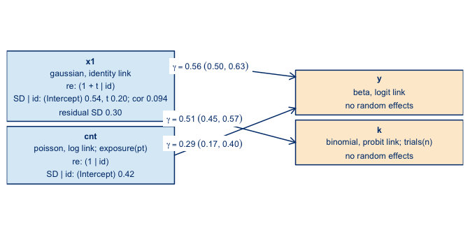

```r
plotModel(m2)
```

## A survival outcome

A time to event with right censoring is written `time | event(status) ~ ...` with `weibullSurvFamily()` or `exponentialSurvFamily()`, one row per subject. The marker enters the hazard at the covariate values of the survival row: `t = 0` below, the subject’s marker level at baseline. The two parts have their own data frames.

```r
set.seed(6)
n <- 200
b0 <- rnorm(n, sd = 0.5); b1 <- rnorm(n, sd = 0.25)
etaS <- function(i, t) 1 + 0.4 * t + b0[i] + b1[i] * t
T <- (-log(runif(n)) / exp(-2.5 + 0.8 * etaS(seq_len(n), 0)))^(1 / 1.5)  # Weibull, alpha 1.5
C <- runif(n, 1, 4)
dSurv <- data.frame(id = sprintf("S%03d", seq_len(n)), time = pmin(T, C),
                    status = as.integer(T <= C), t = 0)
dMark <- data.frame(id = rep(dSurv$id, each = 5), t = rep(c(0, 0.5, 1, 1.5, 2), n))
dMark$x1 <- etaS(rep(seq_len(n), each = 5), dMark$t) + rnorm(nrow(dMark), sd = 0.2)
dMark <- dMark[dMark$t <= rep(dSurv$time, each = 5), ]               # visits before the event

m3 <- jsm(
  list(time | event(status) ~ 1 + scaled(x1),
       x1 ~ 1 + t + (1 + t || id)),
  dataOut = dSurv, dataLong = dMark,
  family  = list(time = weibullSurvFamily())
)
estimatesTable(m3)
```

```
#>  response type        parameter           mean (sd)       95% interval
#>  time     fixed       (Intercept)         -2.7 (0.305)    [-3.3, -2.11]
#>           association gamma (x1 -> time)  0.925 (0.226)   [0.48, 1.37]
#>           family      alpha               1.48 (0.136)    [1.22, 1.75]
#>  x1       fixed       (Intercept)         0.975 (0.0362)  [0.904, 1.05]
#>           fixed       t                   0.378 (0.0245)  [0.33, 0.426]
#>           sd          SD (Intercept) | id 0.485 (0.0264)  [0.436, 0.539]
#>           sd          SD t | id           0.274 (0.0201)  [0.236, 0.315]
#>           residual    residual SD         0.197 (0.00692) [0.184, 0.211]
```

True values: $\gamma = 0.8$ (a log hazard ratio per unit of the marker), Weibull shape $\alpha = 1.5$.

`plot()` draws the survival outcome against its own time: the Kaplan-Meier curve (censored times as open circles) and the model’s survival curve averaged over the subjects. A fit with `inlaOptions = list(control.compute = list(config = TRUE))` adds a 95% band from posterior draws; `survivalCurves()` gives the curves as a data frame.

```r
plot(m3)
```

[interactive chart not shown]

## Several cores, several fits

INLA uses all cores of the machine for one fit by default. `jsm(threads = )` changes that: a number, `"auto"` (the cores `availableThreads()` finds: it respects container limits, SLURM / SGE allocations and `R CMD check`, and on Apple Silicon counts only the performance cores) or `"A:B"` (outer : inner INLA threads). `refit()` and `predict()` take it too.

```r
availableThreads()
```

```
#> [1] 6
#> attr(,"source")
#> [1] "performance cores"
```

Independent fits (candidate models, simulation replicates, predictions by refitting) run in parallel with `jsmApply()`, which divides the core budget among its workers. Here the first model with and without the data-centred prior of the random-effect block:

```r
variants <- list(
  "wishartPrec(scale = \"data\")" = x1 ~ 1 + t + re(1 + t | id, prior = wishartPrec(scale = "data")),
  "INLA's default prior"          = x1 ~ 1 + t + (1 + t | id))
gammas <- jsmApply(variants, function(fx) {
  fit <- jsm(list(y ~ 1 + t + scaled(x1), fx), data = list(y = dY, x1 = dX),
             family = list(y = betaFamily()))
  associations(fit)[, c("mean", "q0.025", "q0.975")]   # return a table, not the model
})
do.call(rbind, gammas)
```

```
#>                                  mean    q0.025    q0.975
#> wishartPrec(scale = "data") 0.8284119 0.7292920 0.9285842
#> INLA's default prior        0.8206258 0.7227617 0.9189663
```

On a 16-core cluster node, four candidate models ran about twice as fast this way as one after another, and simulation studies (many fits of the same model) three to four times as fast; on a laptop, where INLA already keeps the cores busy within one fit, the gain is smaller. Workers are forked copies of the R session on Linux and macOS (in a terminal or `Rscript`); on Windows and in RStudio they are separate R sessions, which load the installed mvrem and receive the variables `FUN` uses. Every worker holds its own fit in memory.

## Overview

| Function | Gives |
| --- | --- |
| `jsm(form, data, family)` | build and fit the model (`fit = FALSE`: build only) |
| `summary()`, `estimatesTable()` | all estimates, readable names |
| `fixedEffects()`, `associations()`, `hyperparameters()`, `coef()` | posterior summaries |
| `randomEffects()`, `varianceComponents()` | subject effects; SDs, correlations, covariance matrices |
| `fittedValues()`, `residuals()`, `modelFit()` | fitted means, residuals; DIC, WAIC, log score |
| `predict(m, newdata)` | posterior of the mean at new rows; `plot()` of the result |
| `plot()`, `plotResiduals()`, `plotRandomEffects()`, `plotVarianceComponents()`, `plotFixedEffects()`, `plotAssociations()` | data and fitted values; diagnostics; posteriors |
| `plotModel()`, `latexEquation()` | diagram and equations of the model |
| `update()`, `refit()` | re-run with changed arguments / INLA options |
| `inlaFormula()`, `inlaData()`, `inlaArguments()`, `inlaFit()`, `formatInlaFormula()` | what was given to INLA, and its result |

Families: `gaussianFamily()`, `studentTFamily()`, `lognormalFamily()`, `gammaFamily()`, `betaFamily()`, `poissonFamily()`, `negBinomialFamily()`, `binomialFamily()`, `betaBinomialFamily()`, zero-inflated Poisson and negative binomial, `weibullSurvFamily()`, `exponentialSurvFamily()` and `inlaFamily()` for any other INLA likelihood. Priors: `gammaPrec()`, `pcSd()`, `halfNormalSd()`, `halfCauchySd()` (also scaled from the data), `wishartPrec()` for correlated blocks and `normalCoef()` for associations. See their help pages for details.